# Part II - Determinants of Prosper Rating and the Benefits of Good Prosper Rating.

## by Godswill Sedem Buabassah

[figure not shown]

## Investigation Overview

> The exploration is to gain insights into the various factors that influence borrower behavior when applying for loans, with a focus on identifying the determinants for aquiring loans. To accomplish this goal, we will concentrate our exploratory efforts on Prosper Rating and Original Loan Amount.

## Summary of Key Insights

> Based on the findings of the study, it can be inferred that the majority of individuals who obtained loans from Prosper used the money to consolidate their debts.

> Although there were no statistical tests conducted to support the claim, borrower income range was observed as an essential factor that influenced Prosper rating. The higher the income range, the better the Prosper rating. The loan amount is influenced by the Income Range of the borrower, with higher incomes being more likely to result in larger loans.

> Borrowers with lower Prosper ratings are more likely to borrow smaller amounts with higher interest rates. On the other hand, borrowers with higher Prosper ratings are more likely to obtain larger loans with lower interest rates.

## Dataset Overview

> Prosper Loans is the first peer-to-peer lending marketplace in the US that has facilitated over 23 billion USD in loans to more than 1.4 million borrowers since its founding in 2005. It offers borrowers fixed-rate, fixed-term loans between USD 2,000 and USD 50,000, while investors can invest in the loans and earn attractive returns.

> The data set contains 113,937 loans with 81 variables. There are both numerical and categorical data with numerical data being majority. The variables of the dataset provides a rich source of information detailing the circumstances of each loan. However after thorough cleaning there are 84853 records with 70 variables and this analysis only focuses on 23 variables.

## Why people go for loans?

> Loans are often taken out by people for a variety of reasons, including making a big purchase, paying for education, consolidating debt, covering unexpected expenses, starting or expanding a business, and others.

> However, majority of Prosper loans are taken for the purposes of debt consolidation.

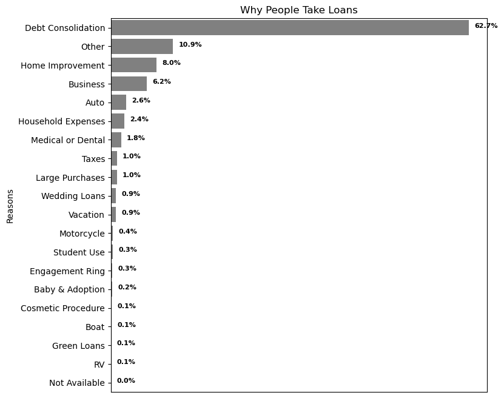

## Determinants of Prosper Rating

> The study also revealed a strong negative correlation between Prosper rating and borrower rate, borrower APR, and lender yield.

> Loan amount had a moderate correlation with Prosper rating, lender yield, and borrower rate and APR.

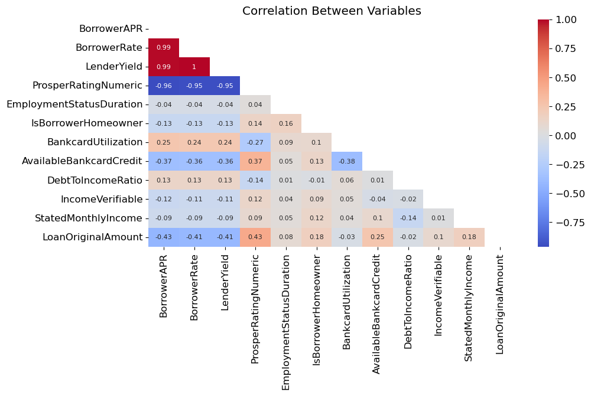

## Confirming The Relationship between Prosper Rating and Interest

> Correlation can be misleading hence the need to confirm with visuals.

> Although there were no statistical tests conducted to support the claim, borrower income range was observed as an essential factor that influenced Prosper rating.

> The loan amount is influenced by the Income Range of the borrower, with higher incomes being more likely to result in larger loans.

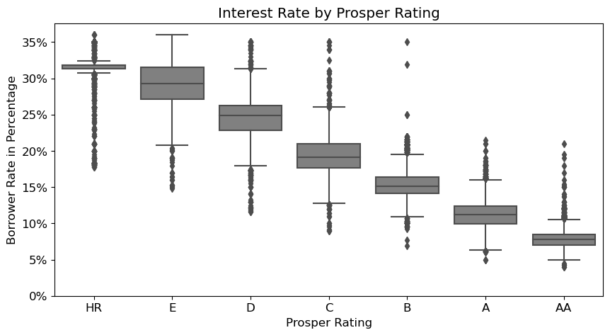

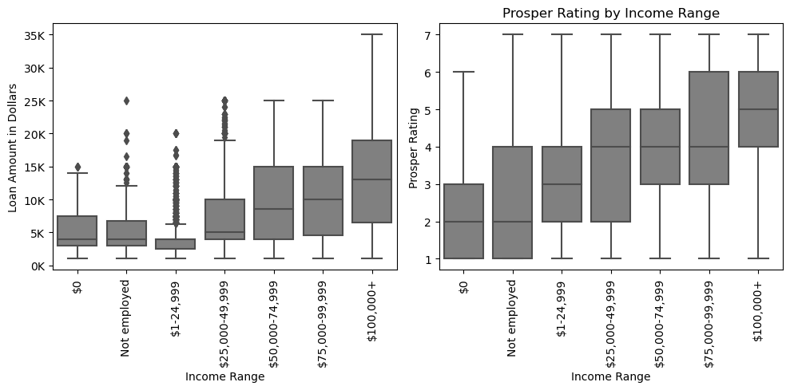

## Benefits of Good Prosper Ratings

> Borrowers with lower Prosper ratings are more likely to borrow smaller amounts with higher interest rates. On the other hand, borrowers with higher Prosper ratings are more likely to obtain larger loans with lower interest rates.

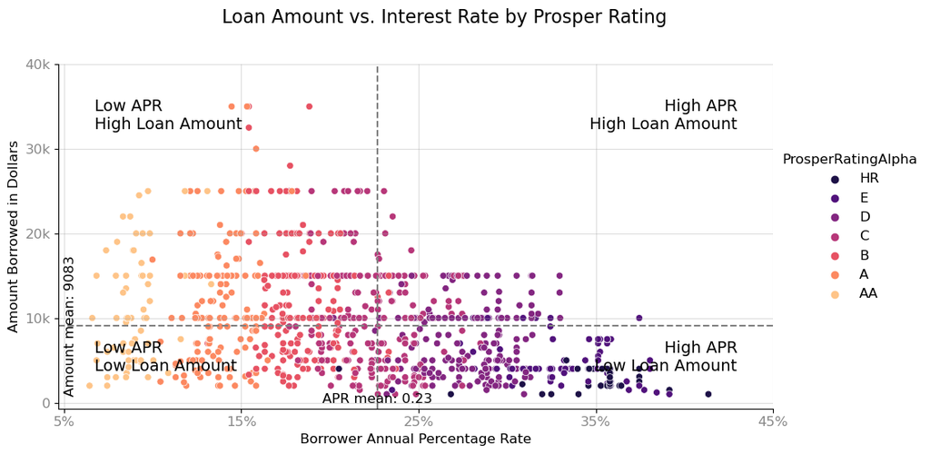